# Forest Fires - GGPLOT

Aaron Wright

28/03/2021

## Introduction

This project is a chance for me to develop my basic R skills, and practice implementing `Ggplot` graphs.

The project itself focses on Forest Fire data. Forest fires can create ecological problems and endanger human lives and property. Understanding when they occur and what causes them is important for managing them. The data I’ll be working with in this project is associated with a scientific research paper on predicting the occurrence of forest fires in Portugal using modeling techniques.

**Variables**

- X: X-axis spatial coordinate within the Montesinho park map: 1 to 9
- Y: Y-axis spatial coordinate within the Montesinho park map: 2 to 9
- month: Month of the year: ‘jan’ to ‘dec’
- day: Day of the week: ‘mon’ to ‘sun’
- FFMC: Fine Fuel Moisture Code index from the FWI system: 18.7 to 96.20
- DMC: Duff Moisture Code index from the FWI system: 1.1 to 291.3
- DC: Drought Code index from the FWI system: 7.9 to 860.6
- ISI: Initial Spread Index from the FWI system: 0.0 to 56.10
- temp: Temperature in Celsius degrees: 2.2 to 33.30
- RH: Relative humidity in percentage: 15.0 to 100
- wind: Wind speed in km/h: 0.40 to 9.40
- rain: Outside rain in mm/m2 : 0.0 to 6.4
- area: The burned area of the forest (in ha): 0.00 to 1090.84

```r
# Load in data
fires <- read_csv("forestfires.csv", col_types = cols())
```

```r
# Explore data
glimpse(fires)
```

```
## Rows: 517
## Columns: 13
## $ X     <dbl> 7, 7, 7, 8, 8, 8, 8, 8, 8, 7, 7, 7, 6, 6, 6, 6, 5, 8, 6, 6, 6, 5…
## $ Y     <dbl> 5, 4, 4, 6, 6, 6, 6, 6, 6, 5, 5, 5, 5, 5, 5, 5, 5, 5, 4, 4, 4, 4…
## $ month <chr> "mar", "oct", "oct", "mar", "mar", "aug", "aug", "aug", "sep", "…
## $ day   <chr> "fri", "tue", "sat", "fri", "sun", "sun", "mon", "mon", "tue", "…
## $ FFMC  <dbl> 86.2, 90.6, 90.6, 91.7, 89.3, 92.3, 92.3, 91.5, 91.0, 92.5, 92.5…
## $ DMC   <dbl> 26.2, 35.4, 43.7, 33.3, 51.3, 85.3, 88.9, 145.4, 129.5, 88.0, 88…
## $ DC    <dbl> 94.3, 669.1, 686.9, 77.5, 102.2, 488.0, 495.6, 608.2, 692.6, 698…
## $ ISI   <dbl> 5.1, 6.7, 6.7, 9.0, 9.6, 14.7, 8.5, 10.7, 7.0, 7.1, 7.1, 22.6, 0…
## $ temp  <dbl> 8.2, 18.0, 14.6, 8.3, 11.4, 22.2, 24.1, 8.0, 13.1, 22.8, 17.8, 1…
## $ RH    <dbl> 51, 33, 33, 97, 99, 29, 27, 86, 63, 40, 51, 38, 72, 42, 21, 44, …
## $ wind  <dbl> 6.7, 0.9, 1.3, 4.0, 1.8, 5.4, 3.1, 2.2, 5.4, 4.0, 7.2, 4.0, 6.7,…
## $ rain  <dbl> 0.0, 0.0, 0.0, 0.2, 0.0, 0.0, 0.0, 0.0, 0.0, 0.0, 0.0, 0.0, 0.0,…
## $ area  <dbl> 0, 0, 0, 0, 0, 0, 0, 0, 0, 0, 0, 0, 0, 0, 0, 0, 0, 0, 0, 0, 0, 0…
```

```r
# Summarising data
summary(fires)
```

```
##        X               Y          month               day
##  Min.   :1.000   Min.   :2.0   Length:517         Length:517
##  1st Qu.:3.000   1st Qu.:4.0   Class :character   Class :character
##  Median :4.000   Median :4.0   Mode  :character   Mode  :character
##  Mean   :4.669   Mean   :4.3
##  3rd Qu.:7.000   3rd Qu.:5.0
##  Max.   :9.000   Max.   :9.0
##       FFMC            DMC              DC             ISI
##  Min.   :18.70   Min.   :  1.1   Min.   :  7.9   Min.   : 0.000
##  1st Qu.:90.20   1st Qu.: 68.6   1st Qu.:437.7   1st Qu.: 6.500
##  Median :91.60   Median :108.3   Median :664.2   Median : 8.400
##  Mean   :90.64   Mean   :110.9   Mean   :547.9   Mean   : 9.022
##  3rd Qu.:92.90   3rd Qu.:142.4   3rd Qu.:713.9   3rd Qu.:10.800
##  Max.   :96.20   Max.   :291.3   Max.   :860.6   Max.   :56.100
##       temp             RH              wind            rain
##  Min.   : 2.20   Min.   : 15.00   Min.   :0.400   Min.   :0.00000
##  1st Qu.:15.50   1st Qu.: 33.00   1st Qu.:2.700   1st Qu.:0.00000
##  Median :19.30   Median : 42.00   Median :4.000   Median :0.00000
##  Mean   :18.89   Mean   : 44.29   Mean   :4.018   Mean   :0.02166
##  3rd Qu.:22.80   3rd Qu.: 53.00   3rd Qu.:4.900   3rd Qu.:0.00000
##  Max.   :33.30   Max.   :100.00   Max.   :9.400   Max.   :6.40000
##       area
##  Min.   :   0.00
##  1st Qu.:   0.00
##  Median :   0.52
##  Mean   :  12.85
##  3rd Qu.:   6.57
##  Max.   :1090.84
```

```r
# Check for missing values
any(is.na(fires))
```

```
## [1] FALSE
```

```r
# Explore actual rows
head(fires)
```

```
## # A tibble: 6 x 13
##       X     Y month day    FFMC   DMC    DC   ISI  temp    RH  wind  rain  area
##   <dbl> <dbl> <chr> <chr> <dbl> <dbl> <dbl> <dbl> <dbl> <dbl> <dbl> <dbl> <dbl>
## 1     7     5 mar   fri    86.2  26.2  94.3   5.1   8.2    51   6.7   0       0
## 2     7     4 oct   tue    90.6  35.4 669.    6.7  18      33   0.9   0       0
## 3     7     4 oct   sat    90.6  43.7 687.    6.7  14.6    33   1.3   0       0
## 4     8     6 mar   fri    91.7  33.3  77.5   9     8.3    97   4     0.2     0
## 5     8     6 mar   sun    89.3  51.3 102.    9.6  11.4    99   1.8   0       0
## 6     8     6 aug   sun    92.3  85.3 488    14.7  22.2    29   5.4   0       0
```

```r
tail(fires)
```

```
## # A tibble: 6 x 13
##       X     Y month day    FFMC   DMC    DC   ISI  temp    RH  wind  rain  area
##   <dbl> <dbl> <chr> <chr> <dbl> <dbl> <dbl> <dbl> <dbl> <dbl> <dbl> <dbl> <dbl>
## 1     8     6 aug   sun    81.6  56.7  666.   1.9  27.8    35   2.7     0  0
## 2     4     3 aug   sun    81.6  56.7  666.   1.9  27.8    32   2.7     0  6.44
## 3     2     4 aug   sun    81.6  56.7  666.   1.9  21.9    71   5.8     0 54.3
## 4     7     4 aug   sun    81.6  56.7  666.   1.9  21.2    70   6.7     0 11.2
## 5     1     4 aug   sat    94.4 146    615.  11.3  25.6    42   4       0  0
## 6     6     3 nov   tue    79.5   3    107.   1.1  11.8    31   4.5     0  0
```

```r
# Check unique values of character columns
unique(c(fires$month, fires$day))
```

```
##  [1] "mar" "oct" "aug" "sep" "apr" "jun" "jul" "feb" "jan" "dec" "may" "nov"
## [13] "fri" "tue" "sat" "sun" "mon" "wed" "thu"
```

```r
# We can also get the min and max of some of the numerical columns
sapply(fires[,5:13], range)
```

```
##      FFMC   DMC    DC  ISI temp  RH wind rain    area
## [1,] 18.7   1.1   7.9  0.0  2.2  15  0.4  0.0    0.00
## [2,] 96.2 291.3 860.6 56.1 33.3 100  9.4  6.4 1090.84
```

The data we have appears to be clean and consistent, with each row represents a forest fire.

Regarding the `days` and `month` attributes, we want to conver these to categories.

```r
# Unique days
fires %>% pull(day) %>% unique
```

```
## [1] "fri" "tue" "sat" "sun" "mon" "wed" "thu"
```

```r
# Convert days to categories
fires$day <- factor(fires$day, levels = c("mon", "tue", "wed", "thu", "fri", "sat", "sun"))
```

```r
# Unique months
fires %>% pull(month) %>% unique
```

```
##  [1] "mar" "oct" "aug" "sep" "apr" "jun" "jul" "feb" "jan" "dec" "may" "nov"
```

```r
# Convert months to categories
fires$month <- factor(fires$month, levels = c("jan", "feb", "mar", "apr", "may", "jun", "jul", "aug", "sep", "oct", "nov", "dec"))
```

```r
# Rechecking the data
glimpse(fires)
```

```
## Rows: 517
## Columns: 13
## $ X     <dbl> 7, 7, 7, 8, 8, 8, 8, 8, 8, 7, 7, 7, 6, 6, 6, 6, 5, 8, 6, 6, 6, 5…
## $ Y     <dbl> 5, 4, 4, 6, 6, 6, 6, 6, 6, 5, 5, 5, 5, 5, 5, 5, 5, 5, 4, 4, 4, 4…
## $ month <fct> mar, oct, oct, mar, mar, aug, aug, aug, sep, sep, sep, sep, aug,…
## $ day   <fct> fri, tue, sat, fri, sun, sun, mon, mon, tue, sat, sat, sat, fri,…
## $ FFMC  <dbl> 86.2, 90.6, 90.6, 91.7, 89.3, 92.3, 92.3, 91.5, 91.0, 92.5, 92.5…
## $ DMC   <dbl> 26.2, 35.4, 43.7, 33.3, 51.3, 85.3, 88.9, 145.4, 129.5, 88.0, 88…
## $ DC    <dbl> 94.3, 669.1, 686.9, 77.5, 102.2, 488.0, 495.6, 608.2, 692.6, 698…
## $ ISI   <dbl> 5.1, 6.7, 6.7, 9.0, 9.6, 14.7, 8.5, 10.7, 7.0, 7.1, 7.1, 22.6, 0…
## $ temp  <dbl> 8.2, 18.0, 14.6, 8.3, 11.4, 22.2, 24.1, 8.0, 13.1, 22.8, 17.8, 1…
## $ RH    <dbl> 51, 33, 33, 97, 99, 29, 27, 86, 63, 40, 51, 38, 72, 42, 21, 44, …
## $ wind  <dbl> 6.7, 0.9, 1.3, 4.0, 1.8, 5.4, 3.1, 2.2, 5.4, 4.0, 7.2, 4.0, 6.7,…
## $ rain  <dbl> 0.0, 0.0, 0.0, 0.2, 0.0, 0.0, 0.0, 0.0, 0.0, 0.0, 0.0, 0.0, 0.0,…
## $ area  <dbl> 0, 0, 0, 0, 0, 0, 0, 0, 0, 0, 0, 0, 0, 0, 0, 0, 0, 0, 0, 0, 0, 0…
```

### When do most forest fires occur.

For this, we have the `month` and `day` columns to work with.

```r
# Group our data by month
month_group <- fires %>%
  group_by(month) %>%
  summarise(total = n())

month_group
```

```
## # A tibble: 12 x 2
##    month total
##  * <fct> <int>
##  1 jan       2
##  2 feb      20
##  3 mar      54
##  4 apr       9
##  5 may       2
##  6 jun      17
##  7 jul      32
##  8 aug     184
##  9 sep     172
## 10 oct      15
## 11 nov       1
## 12 dec       9
```

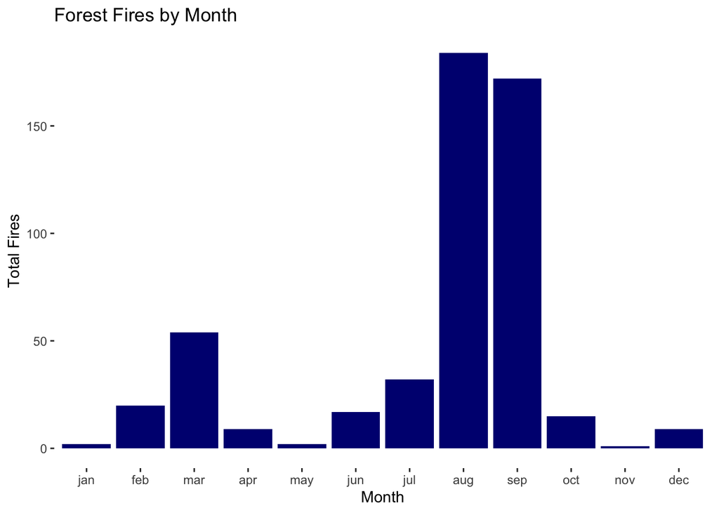

```r
# Creat bar chart
month_group %>%
  ggplot(aes(x = month, y = total))+
  geom_col(fill = "navy") +
  theme(panel.background = element_rect(fill = "white")) +
  labs(
    title = "Forest Fires by Month",
    x = "Month",
    y = "Total Fires"
  )
```

The months with the lowest amount of forest fires are January, May, and November.

Let’s now look at days.

```r
# Group by day
day_group <- fires %>%
  group_by(day) %>%
  summarise(total = n())

day_group
```

```
## # A tibble: 7 x 2
##   day   total
## * <fct> <int>
## 1 mon      74
## 2 tue      64
## 3 wed      54
## 4 thu      61
## 5 fri      85
## 6 sat      84
## 7 sun      95
```

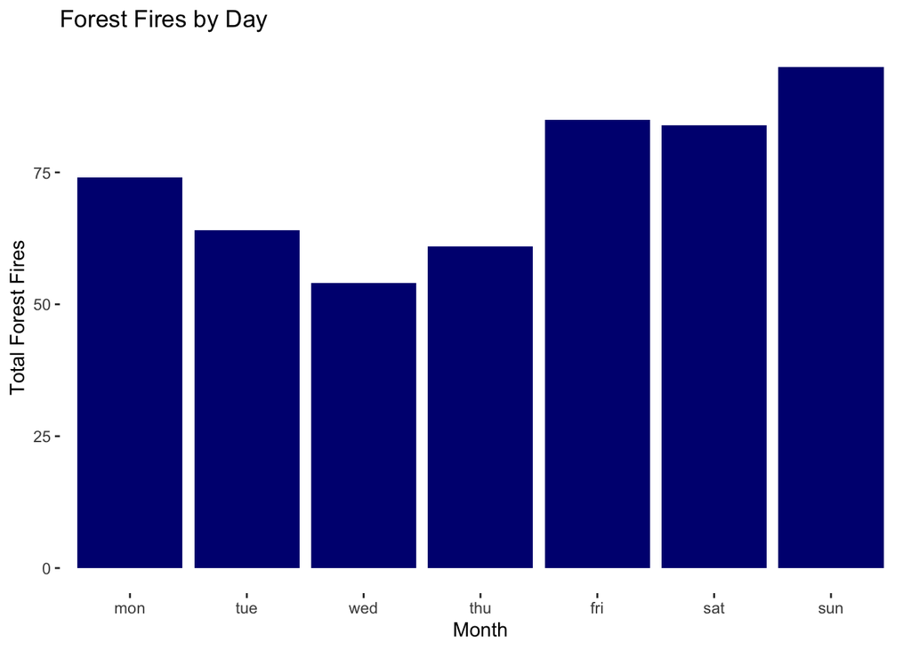

```r
# Create bar chart
day_group %>%
  ggplot(aes(x = day, y = total)) +
  geom_col(fill = "navy") +
  theme(panel.background = element_rect(fill = "white")) +
  labs(
    title = "Forest Fires by Day",
    x = "Month",
    y = "Total Forest Fires"
  )
```

Not a huge amount of variation between days, however the weekend days, friday, saturday and sunday do appear to be the highest.

Now, let’s look at the relationship between `month` and the following columns:

- `FFMC`
- `DMC`
- `DC`
- `ISI`
- `temp`
- `RH`
- `wind`
- `rain`

For this, we might want to use boxplots.

There’s a number of ways to do this. We could plot seperately, or as one. Let’s explore some different ways.

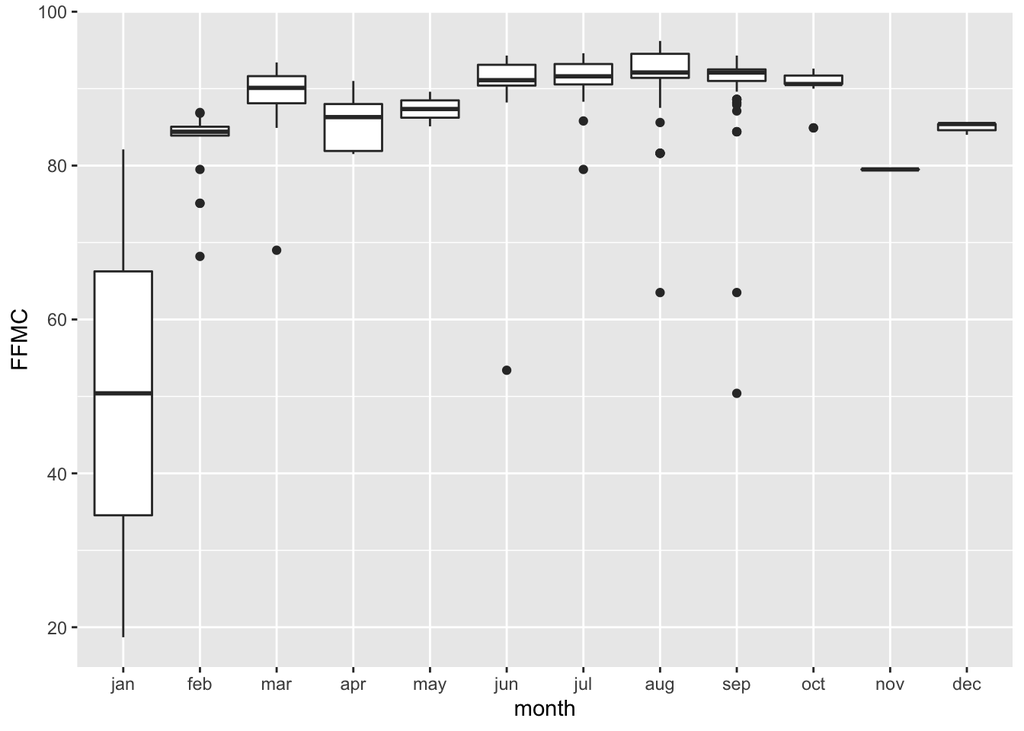

```r
# Plotting individually
fires %>%
  ggplot(aes(x = month, y = FFMC)) +
  geom_boxplot()
```

This may be a bit inefficient. Let’s try plot them all together using `pivot_longer` and `facet_wrap`

```r
# Transform the tibble
fires_pivot <- fires %>%
  pivot_longer(
    cols = c("FFMC", "DMC", "DC", "ISI", "temp", "RH", "wind", "rain"),
    names_to = "columns",
    values_to = "values"
  )

fires_pivot
```

```
## # A tibble: 4,136 x 7
##        X     Y month day    area columns values
##    <dbl> <dbl> <fct> <fct> <dbl> <chr>    <dbl>
##  1     7     5 mar   fri       0 FFMC      86.2
##  2     7     5 mar   fri       0 DMC       26.2
##  3     7     5 mar   fri       0 DC        94.3
##  4     7     5 mar   fri       0 ISI        5.1
##  5     7     5 mar   fri       0 temp       8.2
##  6     7     5 mar   fri       0 RH        51
##  7     7     5 mar   fri       0 wind       6.7
##  8     7     5 mar   fri       0 rain       0
##  9     7     4 oct   tue       0 FFMC      90.6
## 10     7     4 oct   tue       0 DMC       35.4
## # … with 4,126 more rows
```

Next, we will create a plot using `facet_wrap` along with an optional argument `scale` to create multiple graphs. We’ll also set the width and height.

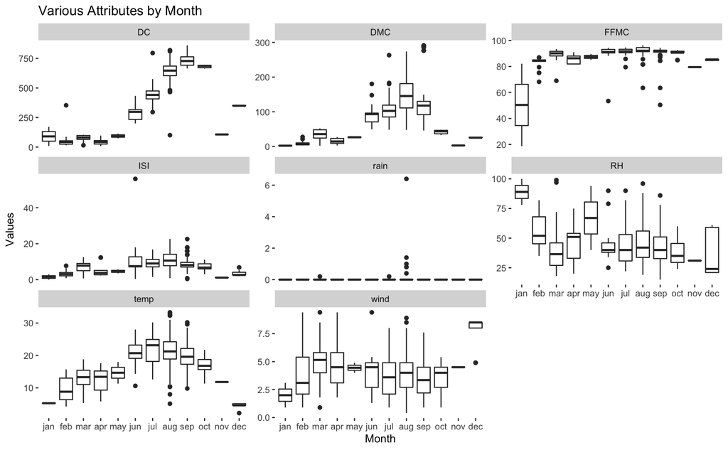

```r
# Create Plots
fires_pivot %>%
  ggplot(aes(x = month, y = values)) +
  geom_boxplot() +
  facet_wrap("columns", scale = "free_y") +
  labs(
    title = "Various Attributes by Month",
    x = "Month",
    y = "Values"
  ) +
  theme(
    panel.background = element_rect(fill = "white")
  )
```